# Attrition Package

This version: December 2021

# 1 Introduction

Attrition, the loss of study units from a sample, can pose a threat to inference. There are several studies, and accompanying R packages, that provide ex-post solutions to missingness such as double-sampling or extreme bounds. However, using the `Attrition` package, you can identify attrition after piloting and prevent it from occurring at the design stage.

# 2 Usage

- Visualizing survey attrition across treatment condition and over-time.
- Utilizing and comparing balace tests at percise moments in the survey.
- Incorporating estimation and visualization of Manski bounds for studies suffering from broblematic attrition.

# 3 Assumptions

- Data must be *ordered by survey questions*, i.e. if respondents answered Q1 before Q2, the variable Q1 must appear before Q2 in the dataframe.
- Skippers, i.e. respondents who skipped questions, are not reported as attrited.

# 4 Arguments

# 5 Example

Let’s begin demonstrating the uses of `Attrition`, with a working example.

After loading the test data (from Lo, Renshon, and Bassan-Nygate 2021, study 5B) and ensuring that variables are ordered by survey questions, we may want to transform our dataframe to an attrition dataframe, using the function `attrition`.

## 5.1 Attrition dataframe

```r
attrition_data <- attrition(test_data)
```

This function creates a frame that indicates, per variable, how many respondents attrited, as well as the proportion of total N attrited which is calculated as *number of attrited respondents / number of respondents entering into the question*.

Using base `R` we can explore how many people attrited overall, and what proportion of the general population this is.

```r
sum(attrition_data$attrited) #How many respondents attrited overall?
```

```
## [1] 129
```

```r
sum(attrition_data$attrited)/nrow(test_data) #What proportion of the overall sample is this? (20%)
```

```
## [1] 0.2067308
```

Next, we can look at specific variables, and learn whether respondents attrited. Let’s choose the variable `cards_a` to demonstrate. Using base `R` we can extract the number of attrited respondents, as well as the proportion of total N attrited, for this question.

```r
attrition_data[attrition_data$questions == 'cards_a', 'attrited']
```

```
## [1] 37
```

```r
attrition_data[attrition_data$questions == 'cards_a', 'proportion']
```

```
## [1] 0.06
```

We learn that at the question `cards_a` 37 respondents attrited from the survey. This is equivalent to 6% of the number of respondents who entered the survey at this question.

## 5.2 Plot attrition

We may want to visualize attrition across the survey, to look at all the survey questions at once. The function `plot_attrition` allows us to plot attrition across survey questions, indicating pre-treatment, treatment, mediators, and outcome questions with different color vertical lines. To do so, use the original `test_data` dataframe, and *not* the `attrition_data`.

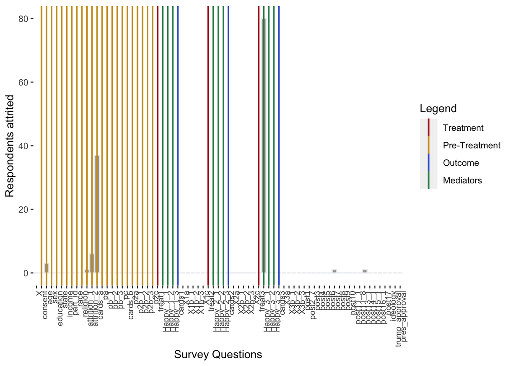

```r
plot_attrition(data = test_data
               ,treatment = c("treat1", "treat2", "treat3")
              ,pre_treatment = c("consent", "age", "sex", "education", "state", "income", "part_id", "race", "religion", "attrition_1", "attrition_2", "cards_a", "pa", "pb_1", "pb_2", "pb_3", "pc", "cards_b", "p2a", "p2b_1", "p2b_2", "p2b_3", "p2c")
               ,DV = c("cards1", "cards2",  "cards3")
               ,other_group = "Mediators"
               ,other_group_var = c("Happy_1_1", "Happy_1_2", "Happy_1_3",
                                    "Happy_2_1", "Happy_2_2", "Happy_2_3",
                                    "Happy_3_1", "Happy_3_2", "Happy_3_3")
               ,freq = TRUE
               )
```

We can also specify `freq = FALSE` so that Y axis will indicate the proportion of total N attrited.

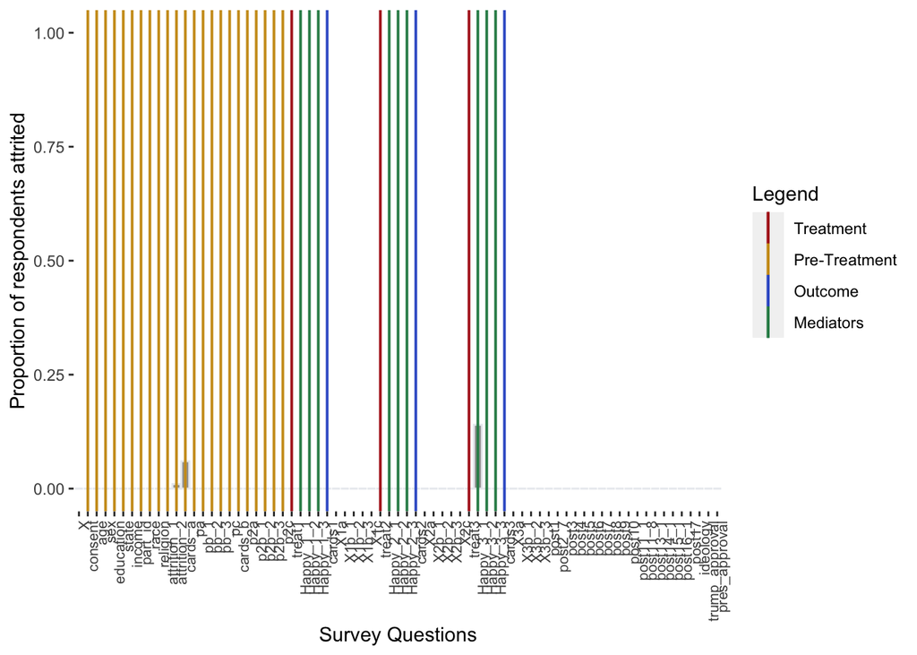

```r
plot_attrition(data = test_data
               ,treatment = c("treat1", "treat2", "treat3")
              ,pre_treatment = c("consent", "age", "sex", "education", "state", "income", "part_id", "race", "religion", "attrition_1", "attrition_2", "cards_a", "pa", "pb_1", "pb_2", "pb_3", "pc", "cards_b", "p2a", "p2b_1", "p2b_2", "p2b_3", "p2c")
               ,DV = c("cards1", "cards2",  "cards3")
               ,other_group = "Mediators"
               ,other_group_var = c("Happy_1_1", "Happy_1_2", "Happy_1_3",
                                    "Happy_2_1", "Happy_2_2", "Happy_2_3",
                                    "Happy_3_1", "Happy_3_2", "Happy_3_3")
               ,freq = FALSE
               )
```

## 5.3 Balance tests

Once we have identified the specific survey points where attrition takes place, we want to conduct balance tests to ensure balance across treatment and control. We can do this using the function `balance`.

We’ve identified that the main post-treatment variable where attrition occurred is `Happy_3_1`. We focus on that since pre-treatment attrition doesn’t pose a threat to internal validity (since non-attriters can still be randomly assigned to arms, probabilistic equivalence can be achieved).

```r
attrition_data[attrition_data$questions == 'Happy_3_1', 'attrited'] #80 respondents attrited
```

```
## [1] 80
```

```r
newdata <- test_data[ which(test_data$treat1=='empathetic'), ]
mean(complete.cases(newdata$Happy_3_1))
```

```
## [1] 0.8715278
```

```r
newdata2 <- test_data[ which(test_data$treat1=='control'), ]
mean(complete.cases(newdata2$Happy_3_1))
```

```
## [1] 0.8512111
```

```r
t.test(newdata$Happy_3_1, newdata2$Happy_3_1)
```

```
##
##  Welch Two Sample t-test
##
## data:  newdata$Happy_3_1 and newdata2$Happy_3_1
## t = 0.58438, df = 494.83, p-value = 0.5592
## alternative hypothesis: true difference in means is not equal to 0
## 95 percent confidence interval:
##  -0.1498085  0.2766507
## sample estimates:
## mean of x mean of y
##  3.079681  3.016260
```

```r
a<-lm(Happy_3_1~treat1, data = test_data)



data_B <- apply(test_data,2,function(x) {ifelse(is.na(x),1,0)})

  #change `skippers` into 0 (we are only interested in respondents that attrited).

  data_B<-apply(data_B,1,skip_to_attrite)
  data_B<-t(data_B) #transpose data

  data_B<-data.frame(data_B)


newdata_A <- data_B[ which(test_data$treat1=='empathetic'), ]
newdata_B <- data_B[ which(test_data$treat1=='control'), ]

t.test(newdata_A$Happy_3_1, newdata_B$Happy_3_1)
```

```
##
##  Welch Two Sample t-test
##
## data:  newdata_A$Happy_3_1 and newdata_B$Happy_3_1
## t = -0.70525, df = 573.07, p-value = 0.4809
## alternative hypothesis: true difference in means is not equal to 0
## 95 percent confidence interval:
##  -0.07689844  0.03626503
## sample estimates:
## mean of x mean of y
## 0.1284722 0.1487889
```